# Deloppgave 5: Analysere repeterte målinger.

## Introduction

Maksimal styrketrening har mange gunstige effekter på god helse hos mennesker, dette kan blant annet være en økning i våres muskelstyrke samt en økning i våres kroppssammensetning.

### Methods

Deltagelse Studien består av 41 deltagere. Disse er mellom 18 og 40 år. Alle deltagerne hadde erfaring med fysisk aktivitet tidligere. Deltagere måtte være skadefrie, ikke bruke røyke samt kun ha trent 1 økt per uke siste 12 månedene. Deltagere som benyttet seg av medisiner som kunne påvirke treningen ble ekskludert. 7 deltagere trente 85% av det som var planlagt og ble fjernet ved analysen. Intervensjon Treningsintervensjonen besto av 12 uker trening med 2-3 styrkeøkter per uke. Alle deltagere trente ulikt volum på hvert bein. Når man trente ulikt volum på de forskjellige beinene vil man kunne se forskjellen mellom ulikt styrketreningsvolum. Hos den enkelte deltagere ble det tilfeldig valgt hvem bein som skulle trene et sett og flere sett. Det ble gjort testet før, under og etter Treningen. Det ble gjort test av muskelstyrke og kroppssammensetning. Underveis ble testene gjort etter 3, 5 og 9 uker.

#### Treningsprotokoll

Oppvarmingen var standardisert, denne inneholdt 5 minutter sykling på en ergometer sykkel. Intensiteten skulle være mellom 12-14 RPM. Neste del av oppvarmingen var 10 repetisjoner av 4 ulike kroppsvekts øvelser (armhevinger, sit-ups, rygghev og knebøy). Siste del av oppvarmingen var 10 repetisjoner av styrkeøvelsene. Her skulle deltagerne løfte 50% av 1RM i den gitte øvelsen. Øvelsene ble gjort i en bestemt rekkefølge. Styrkeøvelsene som skulle gjennomføres på ben var et beins beinpress , hamstring curl og knee extension. De ble kjørt både som enkelt sett og flere sett. Øvelsene for overkropp ble gjennomført etter ben øvelsene. På overkroppen ble det gjennomført to sett med benkpress, nedtrekk og sittende roing eller skulderpress. Disse øvelsene byttet på mellom økter. I dem første 2 ukene av styrketreningen ble det gjennomført 10RM, etter dette ble det gjennomført 3 uker på 8RM. De siste 7 ukene ble gjennomført på 7RM. Pausene ble satt til 90-180 sekunder.

91% av øktene ble gjennomført med tilstedeværelse, de øktene som ikke var det måtte logges.

#### Test av maksimal styrke

Maksimal styrke ble målt i 1RM. Da i øvelsene knee extension og beinpress. Det ble gjennomført en standardisert og spesifikk oppvarming med gjennomføring på 10, 6 og 3 repetisjoner på 50%, 75% og 85%, dette av tenkt 1RM. Etter oppvarming ble vekten økt til deltageren ikke lenger kunne løfte vekten. Godkjent 1RM ble bestemt av en godkjent gjennomføring på høyeste motstand.

#### Kroppssammensetning (DXA)

Kroppssammensetningen ble målt ved hjelp av DXA. Her ble det målt LEAN bodymass. Alle deltagerne måtte faste 12 timer før testen, og heller ikke drevet høyintensitets trening 48 timer før test.

### Resultater

#### Body composition - lean mass

```
## # A tibble: 34 × 5
##    participant sex    include multiple single
##    <chr>       <chr>  <chr>      <dbl>  <dbl>
##  1 FP28        female incl         214    123
##  2 FP40        female incl         -69      2
##  3 FP21        male   incl         619    189
##  4 FP34        female incl         396    312
##  5 FP23        male   incl        -205    445
##  6 FP36        female incl         587    386
##  7 FP38        female incl         -85    225
##  8 FP25        male   incl         373    -47
##  9 FP19        male   incl         302    127
## 10 FP13        male   incl         734    915
## # … with 24 more rows
```

```
##
##  Paired t-test
##
## data:  datlean$multiple and datlean$single
## t = 2.1875, df = 33, p-value = 0.0359
## alternative hypothesis: true mean difference is not equal to 0
## 95 percent confidence interval:
##    8.586109 237.002126
## sample estimates:
## mean difference
##        122.7941
```

The paired t-test compared the change in lean mass from the pretest to the posttest regarding multiple and single set training. The change in lean mass regarding the multiple and single set leg was significant (t(33)=2.1875, p=.0359).

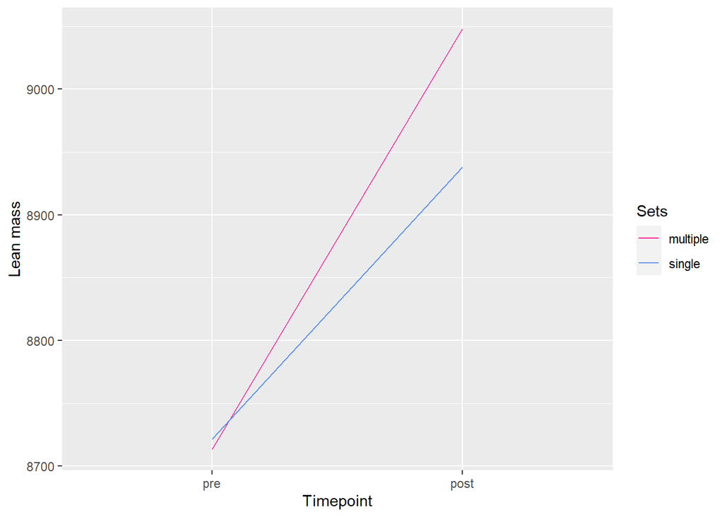

Change in lean mass from pre to post, single vs. multiple sets

#### Maksimal Styrke

```
## # A tibble: 34 × 5
## # Groups:   exercise, participant, sex [34]
##    exercise participant sex    multiple single
##    <chr>    <chr>       <chr>     <dbl>  <dbl>
##  1 legpress FP11        male      185    142.
##  2 legpress FP12        female     80     77.5
##  3 legpress FP13        male      115    110
##  4 legpress FP14        female    126.   114.
##  5 legpress FP15        male       77.5   75
##  6 legpress FP16        female     82.5   65
##  7 legpress FP17        male       52.5   82.5
##  8 legpress FP19        male       65     42.5
##  9 legpress FP2         female     75     42.5
## 10 legpress FP20        female     47.5   55
## # … with 24 more rows
```

```
##
##  Paired t-test
##
## data:  datpress$multiple and datpress$single
## t = 2.1366, df = 29, p-value = 0.0412
## alternative hypothesis: true mean difference is not equal to 0
## 95 percent confidence interval:
##   0.2868145 13.1298522
## sample estimates:
## mean difference
##        6.708333
```

The paired t-test compared the change in maximal muscle strength (leg press) from the pretest to the posttest regarding multiple and single set training. The change in maximal muscle strength (leg press) regarding the multiple and single set leg was significant (t(29)=2.1366, p=.0412).

```
## # A tibble: 34 × 5
## # Groups:   exercise, participant, sex [34]
##    exercise participant sex    multiple single
##    <chr>    <chr>       <chr>     <dbl>  <dbl>
##  1 legext   FP11        male       35    35
##  2 legext   FP12        female     42.5  40
##  3 legext   FP13        male       45    42.5
##  4 legext   FP14        female     20    12.5
##  5 legext   FP15        male       32.5  25
##  6 legext   FP16        female     40    35
##  7 legext   FP17        male       25    30
##  8 legext   FP19        male       12.5   3.75
##  9 legext   FP2         female     20    12.5
## 10 legext   FP20        female     22.5  20
## # … with 24 more rows
```

```
##
##  Paired t-test
##
## data:  datext$multiple and datext$single
## t = 3.3683, df = 31, p-value = 0.002035
## alternative hypothesis: true mean difference is not equal to 0
## 95 percent confidence interval:
##  1.419599 5.777276
## sample estimates:
## mean difference
##        3.598438
```

The paired t-test compared the change in maximal muscle strength (leg extension) from the pretest to the posttest regarding multiple and single set training. The change in maximal muscle strength (leg extension) regarding the multiple and single set leg was significant (t(31)=3.3683, p=.002035).

Losnegard, T., K. Mikkelsen, B. R. Rønnestad, J. Hallén, B. Rud, and T. Raastad. 2011. “The Effect of Heavy Strength Training on Muscle Mass and Physical Performance in Elite Cross Country Skiers.” *Scandinavian Journal of Medicine & Science in Sports* 21 (3): 389–401. https://doi.org/10.1111/j.1600-0838.2009.01074.x.

Styles, William J., Martyn J. Matthews, and Paul Comfort. 2016. “Effects of Strength Training on Squat and Sprint Performance in Soccer Players.” *Journal of Strength and Conditioning Research* 30 (6): 1534–39. https://doi.org/10.1519/JSC.0000000000001243.